# Functions

- A function is a reusable block of code that performs a specific task
- A function is identified by its name (for example, `sqrt`)
- Parentheses `()` indicate that the function is being called
- Values inside the parentheses are called arguments, which are passed to the function as input
- The function executes its internal code using the given arguments
- The function computes a result, which is returned to the caller
- The returned value can be printed, stored in a variable, or used in an expression
- They core of the function code block should be indented by 4 spaces.

wrong code

```
def sum(a,b):
return a+b
```

correct code

```
def sum(a,b):
    return a+b
```

Reference: https://docs.python.org/3/tutorial/controlflow.html#defining-functions

## Function Call and Return

```
flowchart LR
    A[Main program] --> B[Call function]
    B --> C[Function body]
    C --> D[Return value]
    D --> A
```

```python
def sum(x, y):
    # print(x)
    print(x+y)
    # return x+y
sum(1,2)
# print(a)
```

```
3
```

```python
def foo(a):
    sum = 0
    for i in a:
        sum = sum + i
    return sum/len(a)
foo([2,3,4])
```

```
3.0
```

```python
def addElements(a, b):
    return a + b



addElements(2, 3)
addElements(2, 3.1)
addElements(2.3, 4.5)
addElements("python", " workshop")
# addElements(2) # error!
```

```
5
```

```
5.1
```

```
6.8
```

```
'python workshop'
```

```python
# when the order is important!

def subtract(a,b):
    return a-b

subtract(2,3)
subtract(3,2)
subtract(b=3,a=2)
```

```
-1
```

```
1
```

```
-1
```

```python
def greet(name, first='Hello,'):
# def greet(name, first):
    """
    docstring: write something useful!
    """
    # print(f'{first} {name}!')
    return f'{first} {name}!'

print(greet('Sindhu', 'Hello,'))
```

```
Hello, Sindhu!
```

```python
import numpy as np
np.arange(0,10,1)
```

```
array([0, 1, 2, 3, 4, 5, 6, 7, 8, 9])
```

```python
def multdiv(x, y, mult=True):
    """
    this is a horrible function, you shouldn't use this.
    """
    if mult:
        result = x * y
    else:
        result = x / y
    return result

multdiv(2, 2)
multdiv(2, 2, True)
multdiv(2, 2, False)
```

```
4
```

```
4
```

```
1.0
```

```python
def repeat(s, exclaim=False):
    "A completely useless function, but hey it has a docstring!"
    result = s * 3
    if exclaim:
        result += "!!!"
    return result


repeat("Yay, ")
# repeat(3)

# repeat('Yay, ', False)
repeat('Woo ', True)
```

```
'Yay, Yay, Yay, '
```

```
'Woo Woo Woo !!!'
```

```python
# default values for parameters
def addElements(a, b=3):
    return a + b



addElements(2)
addElements(2, 5)
```

```
5
```

```
7
```

# A complete example

with some advanced bits..

```python
def foo(a, b=4):
    c = 3
    return 3+c+a
foo(4,0)
# print(c)
```

```
10
```

```python
# --- GLOBAL SCOPE ---
x = "Global Variable"


def example_function(required_param, default_param="Default Value"):
    """
    DOCSTRING: This is where you explain what the function does. "
    It takes two parameters and returns a formatted string.
    """

    # --- LOCAL SCOPE ---
    # Variables defined here only exist inside this function
    internal_val = "Local Variable"

    result = f"{required_param} | {default_param} | {internal_val}"
    return result
# print(internal_val)
```

```python
# 1. Calling with Positional Arguments
print(example_function("Hello", "Custom Value"))
```

```
Hello | Custom Value | Local Variable
```

```python
# 2. Calling with Keyword Arguments (Order doesn't matter)
print(example_function(default_param="Keyword", required_param="World"))
```

```
World | Keyword | Local Variable
```

```python
# 3. Using Default Argument
print(example_function("Just Required"))
```

```
Just Required | Default Value | Local Variable
```

```python
# 4. Scope demonstration
print(x)  # Works (Global)
# print(internal_val) # NameError (Local scope only)
```

```
Global Variable
```

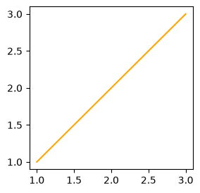

```python
import matplotlib.pyplot as plt
fig,ax= plt.subplots(figsize=(3,3))
ax.plot([1,2,3],[1,2,3],color='orange')
```

```python
# 5. Accessing Docstring
print(example_function.__doc__)
```

```
    DOCSTRING: This is where you explain what the function does. "
    It takes two parameters and returns a formatted string.
```

## Modules and Packages and `__main__`

Python files are modules. When run directly, **name** equals '**main**'. See `example_import.py` and `example_main.py`. For more details check [Python's documentation](https://docs.python.org/3/reference/import.html).

[figure not shown]

[Source: XKCD](https://xkcd.com/353/)

## In the following code block:

Reference: https://docs.python.org/3/library/math.html

```python
import math

math.sqrt(3.498572394)
```

```
1.8704471107197873
```

## Ways to use functions/constants from a module

```python
# import a single function
from random import sample
sample("Luke", 2)
```

```
['L', 'u']
```

```python
# import without an alias. here you need to mention the full name every time you call a function from it, which can get annoying. but it's harmless
import numpy
print(numpy.absolute(-2))
print(numpy.e)
```

```
2
2.718281828459045
```

```python
# import (with an alias). most common use. the aliases could be arbitrary, but there are conventions like numpy -> np etc.

import numpy as np
print(np.absolute(-2))
```

```
2
```

```python
# import the whole module without any alias. this allows to directly call any functions from the module, but this is NOT a good idea (look up in the internet why it's not!)

# from numpy import *
import math
import numpy as np
print(math.e)
print(np.e==math.e)
```

```
2.718281828459045
True
```

```python
# more on namespace https://realpython.com/python-namespace/

x = 3

def square(y):
    """
    this function squares a variable
    """
    y = 2
    return y**2

# y # will return an error

import sum_module
sum_module.sum(2,3)
```

```
5
```

```python
# why should we use loops and functions?
10**2+2
20**2+2
30**2+2
```

```
102
```

```
402
```

```
902
```

```python
lst = [10,20,30]

# lst= list(range(10000))

def func(x):
    return x**2+2

for i in lst:
    print(func(i))
```

```
102
402
902
```

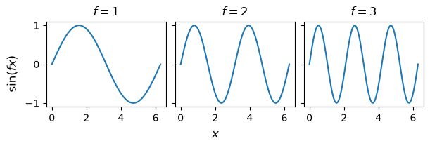

```python
# function use-case
import matplotlib.pyplot as plt
def plot_wave(ax, frequency):
    x = np.linspace(0, 2*np.pi, 100)
    y = np.sin(frequency * x)
    ax.plot(x, y)
    ax.set_title(f"$f = {frequency}$")

fig, axes = plt.subplots(1, 3, figsize=(6, 2), sharey=True, constrained_layout=True)

fig.supylabel(r"$\sin (fx)$")
fig.supxlabel(r'$x$')

for i in range(0,3):
    plot_wave(axes[i], i+1)

# for i, elem in enumerate(axes):
#     plot_wave(elem, i+1)
```

```python
lst1 = ('n1','n2')

a, b = lst1
a
b
```

```
'n1'
```

```
'n2'
```